# Assignment1_GettingStarted_RJ

## Assignment 1: Exploring and Visualizing Data

NOTE : PLEASE DO NOT POST THE CODE OR YOUR SOLUTIONS ON THE WEB/GIT except CANVAS FOR GRADING

This assignment focuses on the EDA process where you load, explore, visualize data and present your findings.

Problem Statement : Choose a variable with meaningful magnitude and examine the effects of two transformations (scaling methods) on that variable.

Background Materials/Data : COVID 19 is an ongoing threat. Data for the outbreak are available here:  
https://www.ecdc.europa.eu/en/publications-data/download-todays-data-geographic-distribution-covid-19-cases-worldwide

Using this data, you are to conduct exploratory data analysis. Provide appropriate descriptive statistics / visualizations to help understand the spread of the disease (incidence) as well as its fatality rate. You should also engage in feature creation and variable transformation. At a bare minimum, feature creation should include generating rates per X in the population (i.e., rates per million). Investigate time series as well as univariate and bivariate distribution graphs.

Select one of variable and perform both min-max and standard scaling in Python.  
reference: https://scikit-learn.org/stable/auto_examples/preprocessing/plot_all_scaling.html#sphx-glr-auto-examples-preprocessing-plot-all-scaling-py

Some methods we will learn in this course (trees and random forests) are unaffected by monotonic transformations of the explanatory variables. Others (SVMs and neural networks) are very much affected by scaling and usually perform better when all explanatory variables have the same scale. It is often best to use scaling methods that preserve the shape of the distribution. But if there are extreme outliers or heavily skewed distributions, then log or normalizing transformations may be warranted.

Questions & Assumptions to Senior Managemment

- What are the management and analytical questions associated with this problem?
- What are some of the assumptions if any ?
- What are your findings/recommendations (if any) based on your analysis of the dataset?

Comment often and in detail, highlighting major sections of code, describing the thinking behind the programming methods being employed.

Python Programming All programming will be done in Python.

-- Grading Guidelines (100 points) 1) Data preparation (20 points) 2) Data exploration (20 points) 3) Data visualization (20 points) 4) Data scaling and comparisons (20 points) 5) Insights from analysis (20 points)

Deliverables and File Formats you can use this notebook to update comments or Provide a double-spaced paper with a two-page maximum for the text. The paper should include all a discussion of all graded elements but focus particularly on insights. Include your Python code and output as an appendix. Upload the notebook and/or as a single .pdf file.

Formatting Python Code Refer to Google’s Python Style Guide (https://google.github.iostyleguide/pyguide.html) for ideas about formatting Python code:

NOTE :

- Below is the starter code and please feel free to update/edit/change to provide your thoughts/solutions to the problem.
- Comment often and in detail, highlighting major sections of code, describing the thinking behind the programming methods being employed.
- This code has a lot of errors (intentionally, including the data dictionary) make sure to updated all the cells based on best practices along with your analysis/findings

```python
# Ignore warnings
import warnings
warnings.filterwarnings("ignore", category=Warning)
```

```python
pip install --upgrade pip
```

```
     |████████████████████████████████| 1.5MB 10.5MB/s
  Found existing installation: pip 19.3.1
    Uninstalling pip-19.3.1:
      Successfully uninstalled pip-19.3.1
```

```python
!pip install prettytable
!pip install geopandas
```

```
     |████████████████████████████████| 994 kB 12.0 MB/s
     |████████████████████████████████| 6.5 MB 31.3 MB/s
     |████████████████████████████████| 14.8 MB 120 kB/s
```

```python
###Loading Packages###
import pandas as pd  # data frame operations
import numpy as np  # arrays and math functions
import matplotlib.pyplot as plt  # static plotting
import seaborn as sns  # pretty plotting, including heat map
import re # regular expressions
import scipy
import os # Operation System
import geopandas as gpd
from prettytable import PrettyTable
import seaborn as sns
import sklearn
import math
from datetime import datetime


import matplotlib as mpl
from matplotlib import pyplot as plt
from matplotlib import cm
from fbprophet import Prophet
from sklearn.preprocessing import minmax_scale
from sklearn.preprocessing import MinMaxScaler
from sklearn.preprocessing import StandardScaler
from sklearn.preprocessing import MaxAbsScaler
from sklearn.preprocessing import StandardScaler
from sklearn.preprocessing import RobustScaler
from sklearn.preprocessing import Normalizer
from sklearn.preprocessing import QuantileTransformer
from sklearn.preprocessing import PowerTransformer
```

```python
# output of plotting commands is displayed inline directly below the code cell that produced it
%matplotlib inline
```

##### Load Data (for Colab/Google Drive)

##### S2 Mount Google Drive to Colab Enviorment

```python
#S2 Mount Google Drive to Colab Enviorment
from google.colab import drive
drive.mount('/content/gdrive')
```

```python
#S3 Establish working directory
import os # Operation System
os.getcwd()
%cd /content/gdrive/My Drive/Machine/HW1/
!pwd
!ls
print('Working Directory')
print(os.getcwd())
```

```
/content/gdrive/My Drive/Machine/HW1
/content/gdrive/My Drive/Machine/HW1
data.csv
Working Directory
/content/gdrive/My Drive/Machine/HW1
```

```python
##### Load Data
##work_dir = " /content/gdrive/My Drive/1/"
##covid19_df=pd.read_csv('./data.csv')
```

```python
# Another way to pull dataset directly from the web
covid19_df = pd.read_csv('https://opendata.ecdc.europa.eu/covid19/casedistribution/csv')
```

```python
# Check few columns to make sure the data is loaded properly
covid19_df.head()
```

|  | dateRep | day | month | year | cases | deaths | countriesAndTerritories | geoId | countryterritoryCode | popData2019 | continentExp | Cumulative_number_for_14_days_of_COVID-19_cases_per_100000 |
| --- | --- | --- | --- | --- | --- | --- | --- | --- | --- | --- | --- | --- |
| 0 | 14/12/2020 | 14 | 12 | 2020 | 746 | 6 | Afghanistan | AF | AFG | 38041757.0 | Asia | 9.013779 |
| 1 | 13/12/2020 | 13 | 12 | 2020 | 298 | 9 | Afghanistan | AF | AFG | 38041757.0 | Asia | 7.052776 |
| 2 | 12/12/2020 | 12 | 12 | 2020 | 113 | 11 | Afghanistan | AF | AFG | 38041757.0 | Asia | 6.868768 |
| 3 | 11/12/2020 | 11 | 12 | 2020 | 63 | 10 | Afghanistan | AF | AFG | 38041757.0 | Asia | 7.134266 |
| 4 | 10/12/2020 | 10 | 12 | 2020 | 202 | 16 | Afghanistan | AF | AFG | 38041757.0 | Asia | 6.968658 |

#### Common functions/libraries

```python
# correlation heat map setup for seaborn
def corr_chart(df_corr):
    corr=df_corr.corr()
    #screen top half to get a triangle
    top = np.zeros_like(corr, dtype=np.bool)
    top[np.triu_indices_from(top)] = True
    fig=plt.figure()
    fig, ax = plt.subplots(figsize=(12,12))
    sns.heatmap(corr, mask=top, cmap='coolwarm',
        center = 0, square=True,
        linewidths=.5, cbar_kws={'shrink':.5},
        annot = True, annot_kws={'size': 9}, fmt = '.3f')
    plt.xticks(rotation=45) # rotate variable labels on columns (x axis)
    plt.yticks(rotation=0) # use horizontal variable labels on rows (y axis)
    plt.title('Correlation Heat Map')
    plt.show()
    plt.close()

np.set_printoptions(precision=3)
```

```python
# overrides the default rcParams for plotting
def init_plotting():
    plt.style.use(style='ggplot')
    plt.rcParams['figure.figsize'] = (10.0, 8.0)
    plt.rcParams['font.family'] = 'serif'
    plt.rcParams['text.color'] = 'black'
    plt.rcParams['axes.labelcolor'] = 'black'
    plt.rcParams['xtick.color']= 'black'
    plt.rcParams['ytick.color']= 'black'

init_plotting()

# avoid empty plot, always good to close plot
plt.close()
```

#### Exploratory Data Analysis (EDA)

```python
# Get an understanding of the data
print("Shape:", covid19_df.shape,"\n")
print("Variable Types:")
print(covid19_df.dtypes)

covid19_df.head(15)
```

```
Shape: (61900, 12)

Variable Types:
dateRep                                                        object
day                                                             int64
month                                                           int64
year                                                            int64
cases                                                           int64
deaths                                                          int64
countriesAndTerritories                                        object
geoId                                                          object
countryterritoryCode                                           object
popData2019                                                   float64
continentExp                                                   object
Cumulative_number_for_14_days_of_COVID-19_cases_per_100000    float64
dtype: object
```

|  | dateRep | day | month | year | cases | deaths | countriesAndTerritories | geoId | countryterritoryCode | popData2019 | continentExp | Cumulative_number_for_14_days_of_COVID-19_cases_per_100000 |
| --- | --- | --- | --- | --- | --- | --- | --- | --- | --- | --- | --- | --- |
| 0 | 14/12/2020 | 14 | 12 | 2020 | 746 | 6 | Afghanistan | AF | AFG | 38041757.0 | Asia | 9.013779 |
| 1 | 13/12/2020 | 13 | 12 | 2020 | 298 | 9 | Afghanistan | AF | AFG | 38041757.0 | Asia | 7.052776 |
| 2 | 12/12/2020 | 12 | 12 | 2020 | 113 | 11 | Afghanistan | AF | AFG | 38041757.0 | Asia | 6.868768 |
| 3 | 11/12/2020 | 11 | 12 | 2020 | 63 | 10 | Afghanistan | AF | AFG | 38041757.0 | Asia | 7.134266 |
| 4 | 10/12/2020 | 10 | 12 | 2020 | 202 | 16 | Afghanistan | AF | AFG | 38041757.0 | Asia | 6.968658 |
| 5 | 09/12/2020 | 9 | 12 | 2020 | 135 | 13 | Afghanistan | AF | AFG | 38041757.0 | Asia | 6.963401 |
| 6 | 08/12/2020 | 8 | 12 | 2020 | 200 | 6 | Afghanistan | AF | AFG | 38041757.0 | Asia | 7.094835 |
| 7 | 07/12/2020 | 7 | 12 | 2020 | 210 | 26 | Afghanistan | AF | AFG | 38041757.0 | Asia | 7.215755 |
| 8 | 06/12/2020 | 6 | 12 | 2020 | 234 | 10 | Afghanistan | AF | AFG | 38041757.0 | Asia | 7.326160 |
| 9 | 05/12/2020 | 5 | 12 | 2020 | 235 | 18 | Afghanistan | AF | AFG | 38041757.0 | Asia | 7.115865 |
| 10 | 04/12/2020 | 4 | 12 | 2020 | 119 | 5 | Afghanistan | AF | AFG | 38041757.0 | Asia | 7.107979 |
| 11 | 03/12/2020 | 3 | 12 | 2020 | 202 | 19 | Afghanistan | AF | AFG | 38041757.0 | Asia | 7.536455 |
| 12 | 02/12/2020 | 2 | 12 | 2020 | 400 | 48 | Afghanistan | AF | AFG | 38041757.0 | Asia | 7.005460 |
| 13 | 01/12/2020 | 1 | 12 | 2020 | 272 | 11 | Afghanistan | AF | AFG | 38041757.0 | Asia | 6.960772 |
| 14 | 30/11/2020 | 30 | 11 | 2020 | 0 | 0 | Afghanistan | AF | AFG | 38041757.0 | Asia | 6.416633 |

```python
### examine the structure of the DataFrame object###
print('\nContents of covid19 data ---------------')

# could use len() or first index of shape() to get number of rows/observations
print('\nNumber of Cases =', len(covid19_df), '\n')

# show the column/variable names of the DataFrame
# note that RespondentID is no longer present
covid19_df.columns

# abbreviated printing of the first five rows of the data frame
print(pd.DataFrame.head(covid19_df))
```

```
Contents of covid19 data ---------------

Number of Cases = 61900

      dateRep  ...  Cumulative_number_for_14_days_of_COVID-19_cases_per_100000
0  14/12/2020  ...                                           9.013779
1  13/12/2020  ...                                           7.052776
2  12/12/2020  ...                                           6.868768
3  11/12/2020  ...                                           7.134266
4  10/12/2020  ...                                           6.968658

[5 rows x 12 columns]
```

```python
# Number of countries
len(covid19_df.countriesAndTerritories.unique())
```

```
214
```

Attention to the **count** row will indicate if column has missing records

```python
# summary statistics
covid19_df.describe()
```

|  | day | month | year | cases | deaths | popData2019 | Cumulative_number_for_14_days_of_COVID-19_cases_per_100000 |
| --- | --- | --- | --- | --- | --- | --- | --- |
| count | 61900.000000 | 61900.000000 | 61900.000000 | 61900.000000 | 61900.000000 | 6.177700e+04 | 59021.000000 |
| mean | 15.628934 | 7.067157 | 2019.998918 | 1155.147237 | 26.055460 | 4.098770e+07 | 66.320586 |
| std | 8.841582 | 2.954776 | 0.032882 | 6779.224479 | 131.227055 | 1.531294e+08 | 162.329240 |
| min | 1.000000 | 1.000000 | 2019.000000 | -8261.000000 | -1918.000000 | 8.150000e+02 | -147.419587 |
| 25% | 8.000000 | 5.000000 | 2020.000000 | 0.000000 | 0.000000 | 1.293120e+06 | 0.757526 |
| 50% | 15.000000 | 7.000000 | 2020.000000 | 15.000000 | 0.000000 | 7.169456e+06 | 6.724045 |
| 75% | 23.000000 | 10.000000 | 2020.000000 | 273.000000 | 4.000000 | 2.851583e+07 | 52.572719 |
| max | 31.000000 | 12.000000 | 2020.000000 | 234633.000000 | 4928.000000 | 1.433784e+09 | 1900.836210 |

### Review Dataset for Missing Values

Review dataset for missing records

```python
covid19_df.isnull().sum()
```

```
dateRep                                                          0
day                                                              0
month                                                            0
year                                                             0
cases                                                            0
deaths                                                           0
countriesAndTerritories                                          0
geoId                                                          275
countryterritoryCode                                           123
popData2019                                                    123
continentExp                                                     0
Cumulative_number_for_14_days_of_COVID-19_cases_per_100000    2879
dtype: int64
```

## Preprocess Data for Analysis

#### Date Column formatted into ISO 8601 standard format (Year - Month - Day)

```python
# Save original dataset before transformations for later retrieval
covid19_df['dateRep']=pd.to_datetime(covid19_df['dateRep'], format='%d/%m/%Y').dt.strftime('%Y%m%d')
covid19_df['dateRep']=pd.to_datetime(covid19_df['dateRep'], format='%Y/%m/%d')
covid19_df['dateRep'].head()
```

```
0   2020-12-14
1   2020-12-13
2   2020-12-12
3   2020-12-11
4   2020-12-10
Name: dateRep, dtype: datetime64[ns]
```

#### Review Data Types (dtypes)

```python
covid19_df.dtypes
```

```
dateRep                                                       datetime64[ns]
day                                                                    int64
month                                                                  int64
year                                                                   int64
cases                                                                  int64
deaths                                                                 int64
countriesAndTerritories                                               object
geoId                                                                 object
countryterritoryCode                                                  object
popData2019                                                          float64
continentExp                                                          object
Cumulative_number_for_14_days_of_COVID-19_cases_per_100000           float64
dtype: object
```

```python
covid19_df.isnull().sum()
```

```
dateRep                                                          0
day                                                              0
month                                                            0
year                                                             0
cases                                                            0
deaths                                                           0
countriesAndTerritories                                          0
geoId                                                          275
countryterritoryCode                                           123
popData2019                                                    123
continentExp                                                     0
Cumulative_number_for_14_days_of_COVID-19_cases_per_100000    2879
dtype: int64
```

```python
covid19_df.head()
```

|  | dateRep | day | month | year | cases | deaths | countriesAndTerritories | geoId | countryterritoryCode | popData2019 | continentExp | Cumulative_number_for_14_days_of_COVID-19_cases_per_100000 |
| --- | --- | --- | --- | --- | --- | --- | --- | --- | --- | --- | --- | --- |
| 0 | 2020-12-14 | 14 | 12 | 2020 | 746 | 6 | Afghanistan | AF | AFG | 38041757.0 | Asia | 9.013779 |
| 1 | 2020-12-13 | 13 | 12 | 2020 | 298 | 9 | Afghanistan | AF | AFG | 38041757.0 | Asia | 7.052776 |
| 2 | 2020-12-12 | 12 | 12 | 2020 | 113 | 11 | Afghanistan | AF | AFG | 38041757.0 | Asia | 6.868768 |
| 3 | 2020-12-11 | 11 | 12 | 2020 | 63 | 10 | Afghanistan | AF | AFG | 38041757.0 | Asia | 7.134266 |
| 4 | 2020-12-10 | 10 | 12 | 2020 | 202 | 16 | Afghanistan | AF | AFG | 38041757.0 | Asia | 6.968658 |

```python
covid19_df.shape
```

```
(61900, 12)
```

```python
covid19_df.dtypes
```

```
dateRep                                                       datetime64[ns]
day                                                                    int64
month                                                                  int64
year                                                                   int64
cases                                                                  int64
deaths                                                                 int64
countriesAndTerritories                                               object
geoId                                                                 object
countryterritoryCode                                                  object
popData2019                                                          float64
continentExp                                                          object
Cumulative_number_for_14_days_of_COVID-19_cases_per_100000           float64
dtype: object
```

## Visualizing Data

```
array([[<matplotlib.axes._subplots.AxesSubplot object at 0x7f7aa3245a50>,
      dtype=object)
```

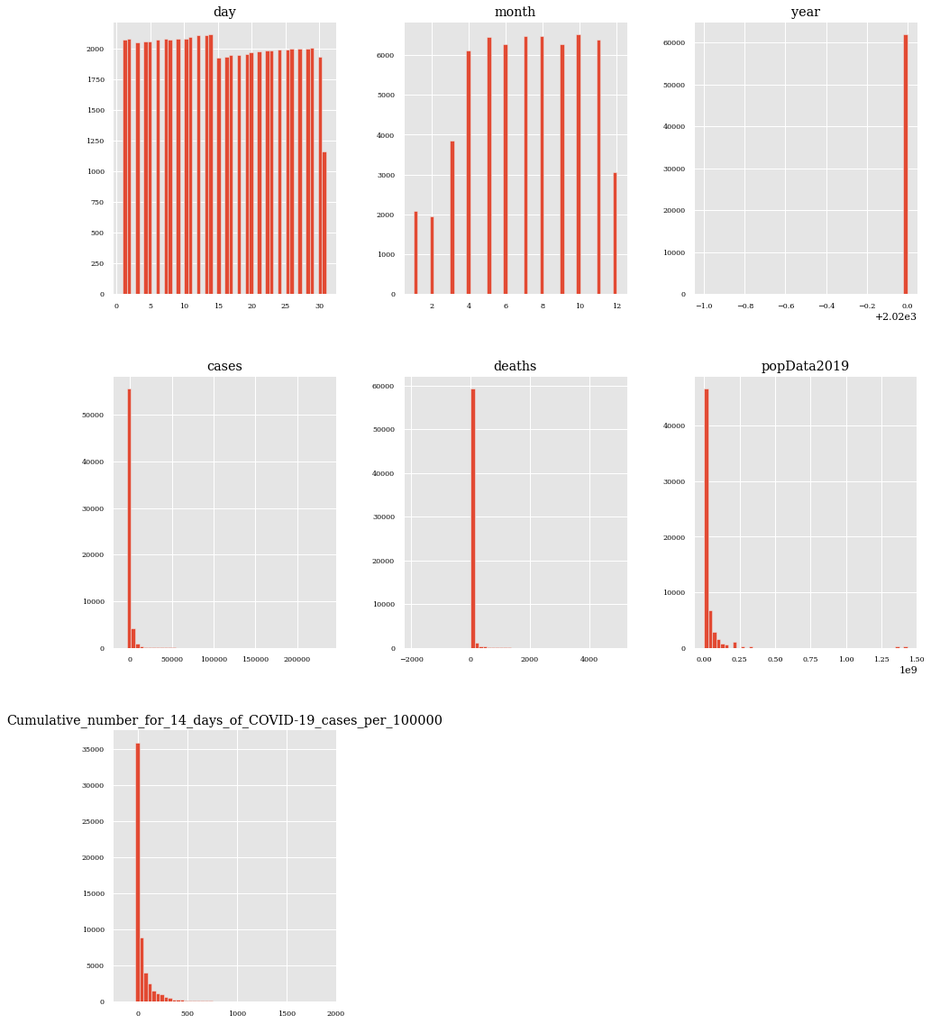

```python
# Distribution of the numerical varialbes
list(set(covid19_df.dtypes.tolist()))

df_num = covid19_df.select_dtypes(include = ['float64', 'int64'])
df_num.hist(figsize=(16, 20), bins=50, xlabelsize=8, ylabelsize=8)
```

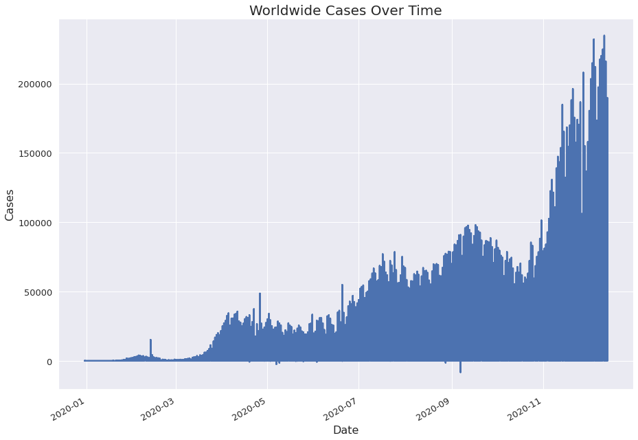

```python
# How are the worldwise cases trending over time ?
world_daily = covid19_df.set_index('dateRep')
sns.set_color_codes("colorblind")
sns.set(rc={'figure.figsize':(15, 11)})
world_daily['cases'].plot(linewidth = 2.5)


plt.title('Worldwide Cases Over Time', fontsize = 20)
plt.xlabel('Date', fontsize = 16)
plt.xticks(fontsize = 13)
plt.ylabel('Cases', fontsize = 16)
plt.yticks(fontsize = 13)

plt.show()
```

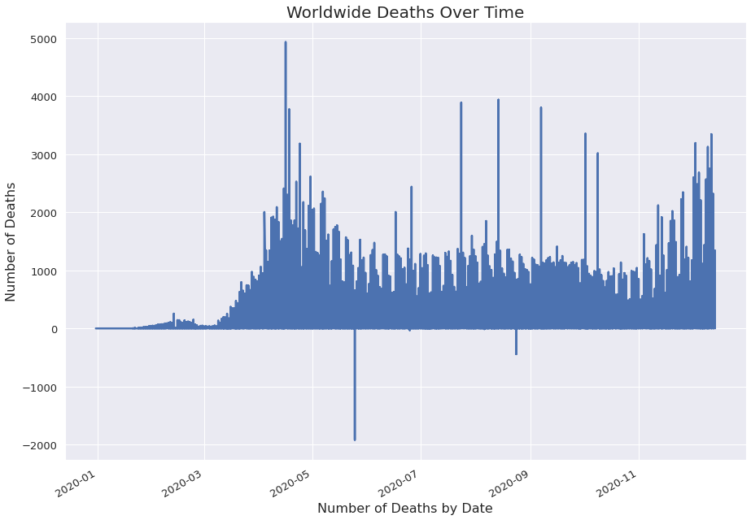

```python
# How are the worldwide Deaths trending over time ?
sns.set(rc={'figure.figsize':(15,11)})
world_daily['deaths'].plot(linewidth = 2.5)


plt.title('Worldwide Deaths Over Time', fontsize = 20)
plt.xlabel('Number of Deaths by Date', fontsize = 16)
plt.xticks(fontsize = 13)
plt.ylabel('Number of Deaths', fontsize = 16)
plt.yticks(fontsize = 13)

plt.show()
```

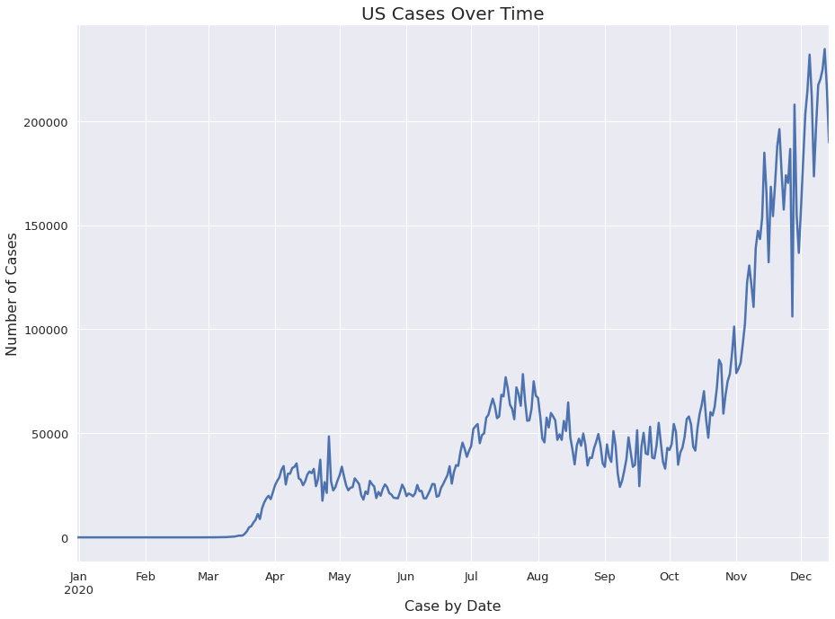

```python
UScovid19_df = covid19_df[covid19_df["countriesAndTerritories"] == "United_States_of_America"].reset_index()
US_daily = UScovid19_df.set_index('dateRep')

sns.set(rc={'figure.figsize':(15, 11)})
US_daily['cases'].plot(linewidth = 2.5)

plt.title('US Cases Over Time', fontsize = 20)
plt.xlabel('Case by Date', fontsize = 16)
plt.xticks(fontsize = 13)
plt.ylabel('Number of Cases', fontsize = 16)
plt.yticks(fontsize = 13)

plt.show()
```

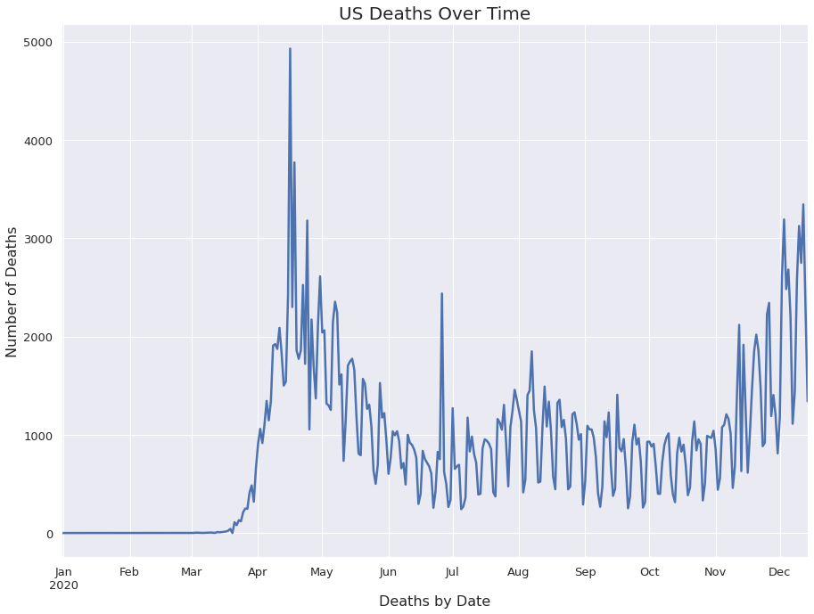

```python
UScovid19_df = covid19_df[covid19_df["countriesAndTerritories"] == "United_States_of_America"].reset_index()
US_daily = UScovid19_df.set_index('dateRep')

sns.set(rc={'figure.figsize':(15, 11)})
US_daily['deaths'].plot(linewidth = 2.5)

plt.title('US Deaths Over Time', fontsize = 20)
plt.xlabel('Deaths by Date', fontsize = 16)
plt.xticks(fontsize = 13)
plt.ylabel('Number of Deaths', fontsize = 16)
plt.yticks(fontsize = 13)

plt.show()
```

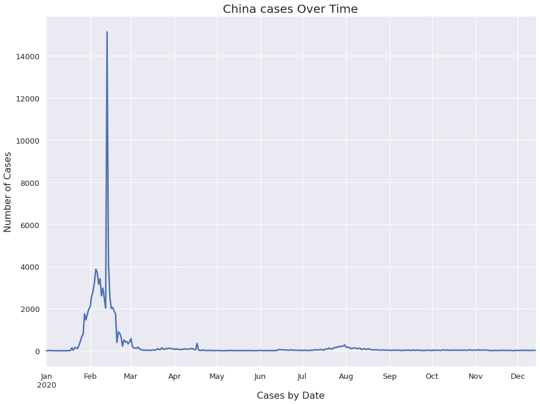

```python
# China cases over time
Chinacovid19_df = covid19_df[covid19_df["countriesAndTerritories"] == "China"].reset_index()
China_daily = Chinacovid19_df.set_index('dateRep')

sns.set(rc={'figure.figsize':(15, 11)})
China_daily['cases'].plot(linewidth = 2.5)

plt.title('China cases Over Time', fontsize = 20)
plt.xlabel('Cases by Date', fontsize = 16)
plt.xticks(fontsize = 13)
plt.ylabel('Number of Cases', fontsize = 16)
plt.yticks(fontsize = 13)

plt.show()
```

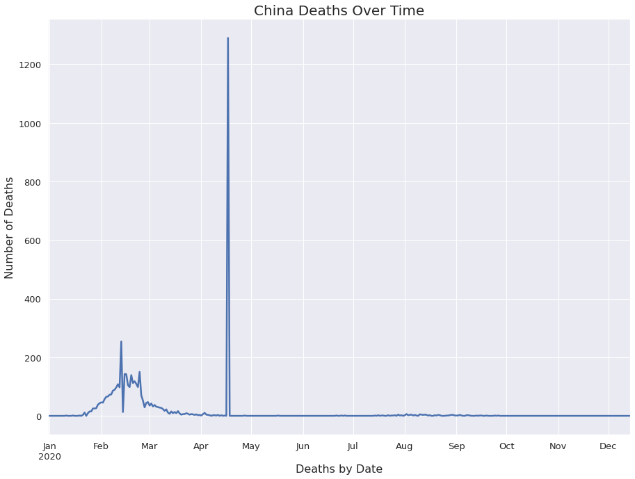

```python
# China Death over time
Chinacovid19_df = covid19_df[covid19_df["countriesAndTerritories"] == "China"].reset_index()
China_daily = Chinacovid19_df.set_index('dateRep')

sns.set(rc={'figure.figsize':(15, 11)})
China_daily['deaths'].plot(linewidth = 2.5)

plt.title('China Deaths Over Time', fontsize = 20)
plt.xlabel('Deaths by Date', fontsize = 16)
plt.xticks(fontsize = 13)
plt.ylabel('Number of Deaths', fontsize = 16)
plt.yticks(fontsize = 13)

plt.show()
```

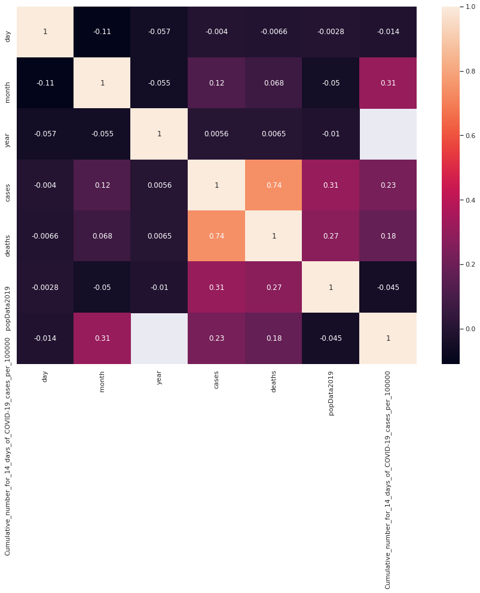

```python
# Corrleation matrix
sns.heatmap(covid19_df.corr(),annot=True)
```

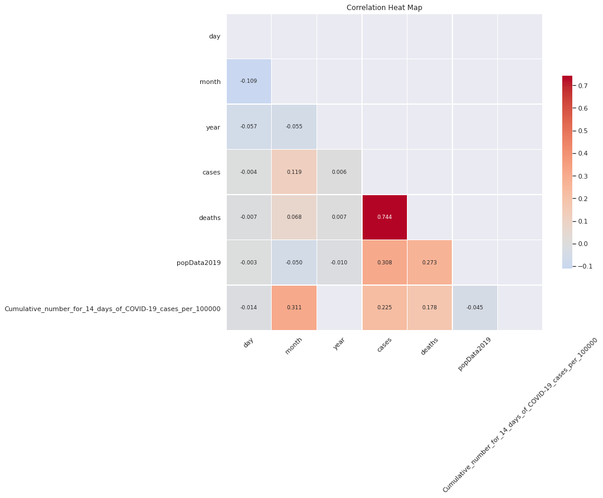

```python
#Correlation Heat Map
corr_chart(df_num)
```

#### Data Analysis, Scaling & Comparisons

```python
#creating a sub dataframe for only the US, also sorting by date to create new features cumulative Cases and cumulative Deaths
dfus=covid19_df[covid19_df["countriesAndTerritories"] == "United_States_of_America"].copy().sort_values(by='dateRep').reset_index().drop(columns=['index'])
#creating new features cumCases and cumDeaths
dfus['usCumulativeCases'] = dfus['cases'].cumsum(axis = 0)
dfus['cumulativeDeaths'] = dfus['deaths'].cumsum(axis = 0)

dfus[60:65]
```

|  | dateRep | day | month | year | cases | deaths | countriesAndTerritories | geoId | countryterritoryCode | popData2019 | continentExp | Cumulative_number_for_14_days_of_COVID-19_cases_per_100000 | usCumulativeCases | cumulativeDeaths |
| --- | --- | --- | --- | --- | --- | --- | --- | --- | --- | --- | --- | --- | --- | --- |
| 60 | 2020-02-29 | 29 | 2 | 2020 | 6 | 0 | United_States_of_America | US | USA | 329064917.0 | America | 0.015498 | 66 | 0 |
| 61 | 2020-03-01 | 1 | 3 | 2020 | 3 | 1 | United_States_of_America | US | USA | 329064917.0 | America | 0.016410 | 69 | 1 |
| 62 | 2020-03-02 | 2 | 3 | 2020 | 20 | 1 | United_States_of_America | US | USA | 329064917.0 | America | 0.022488 | 89 | 2 |
| 63 | 2020-03-03 | 3 | 3 | 2020 | 14 | 4 | United_States_of_America | US | USA | 329064917.0 | America | 0.026742 | 103 | 6 |
| 64 | 2020-03-04 | 4 | 3 | 2020 | 22 | 3 | United_States_of_America | US | USA | 329064917.0 | America | 0.033428 | 125 | 9 |

```python
#create two new features casesPer100000 and fatalityRate
dfus['casesPer100000']=dfus['cases']/(329064917/100000)
dfus['fatalityRate']=(dfus['deaths']/dfus['cases']).fillna(0)
dfus.head()
```

|  | dateRep | day | month | year | cases | deaths | countriesAndTerritories | geoId | countryterritoryCode | popData2019 | continentExp | Cumulative_number_for_14_days_of_COVID-19_cases_per_100000 | usCumulativeCases | cumulativeDeaths | casesPer100000 | fatalityRate |
| --- | --- | --- | --- | --- | --- | --- | --- | --- | --- | --- | --- | --- | --- | --- | --- | --- |
| 0 | 2019-12-31 | 31 | 12 | 2019 | 0 | 0 | United_States_of_America | US | USA | 329064917.0 | America | NaN | 0 | 0 | 0.0 | 0.0 |
| 1 | 2020-01-01 | 1 | 1 | 2020 | 0 | 0 | United_States_of_America | US | USA | 329064917.0 | America | NaN | 0 | 0 | 0.0 | 0.0 |
| 2 | 2020-01-02 | 2 | 1 | 2020 | 0 | 0 | United_States_of_America | US | USA | 329064917.0 | America | NaN | 0 | 0 | 0.0 | 0.0 |
| 3 | 2020-01-03 | 3 | 1 | 2020 | 0 | 0 | United_States_of_America | US | USA | 329064917.0 | America | NaN | 0 | 0 | 0.0 | 0.0 |
| 4 | 2020-01-04 | 4 | 1 | 2020 | 0 | 0 | United_States_of_America | US | USA | 329064917.0 | America | NaN | 0 | 0 | 0.0 | 0.0 |

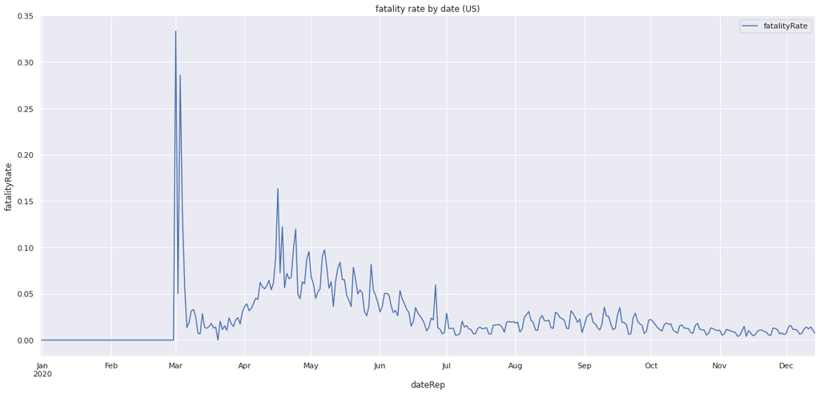

```python
#taking a look of the fatality rate by date
ax = dfus.plot(x = 'dateRep', y ='fatalityRate', figsize=(20,9), title='fatality rate by date (US)')
ax.set_xlabel("dateRep")
ax.set_ylabel("fatalityRate")
```

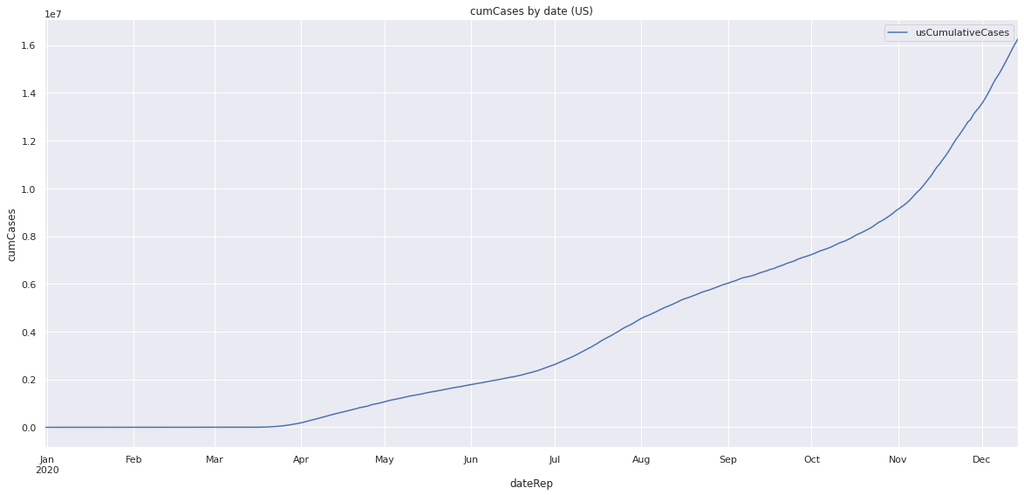

```python
#taking a look of the cummulative cases number by date
ax2 = dfus.plot(x = 'dateRep', y ='usCumulativeCases', figsize=(20,9), title='cumCases by date (US)')
ax2.set_xlabel("dateRep")
ax2.set_ylabel("cumCases")
```

```python
# Do the similar thing to india
dfindia=covid19_df[covid19_df["countriesAndTerritories"] == "India"].copy().sort_values(by='dateRep').reset_index().drop(columns=['index'])
```

```python
dfindia['casesPer100000']=dfindia['cases']/(1.366418e+09	/100000)
dfindia['fatalityRate']=(dfindia['deaths']/dfindia['cases']).fillna(0)
dfindia.head()
```

|  | dateRep | day | month | year | cases | deaths | countriesAndTerritories | geoId | countryterritoryCode | popData2019 | continentExp | Cumulative_number_for_14_days_of_COVID-19_cases_per_100000 | casesPer100000 | fatalityRate |
| --- | --- | --- | --- | --- | --- | --- | --- | --- | --- | --- | --- | --- | --- | --- |
| 0 | 2019-12-31 | 31 | 12 | 2019 | 0 | 0 | India | IN | IND | 1.366418e+09 | Asia | NaN | 0.0 | 0.0 |
| 1 | 2020-01-01 | 1 | 1 | 2020 | 0 | 0 | India | IN | IND | 1.366418e+09 | Asia | NaN | 0.0 | 0.0 |
| 2 | 2020-01-02 | 2 | 1 | 2020 | 0 | 0 | India | IN | IND | 1.366418e+09 | Asia | NaN | 0.0 | 0.0 |
| 3 | 2020-01-03 | 3 | 1 | 2020 | 0 | 0 | India | IN | IND | 1.366418e+09 | Asia | NaN | 0.0 | 0.0 |
| 4 | 2020-01-04 | 4 | 1 | 2020 | 0 | 0 | India | IN | IND | 1.366418e+09 | Asia | NaN | 0.0 | 0.0 |

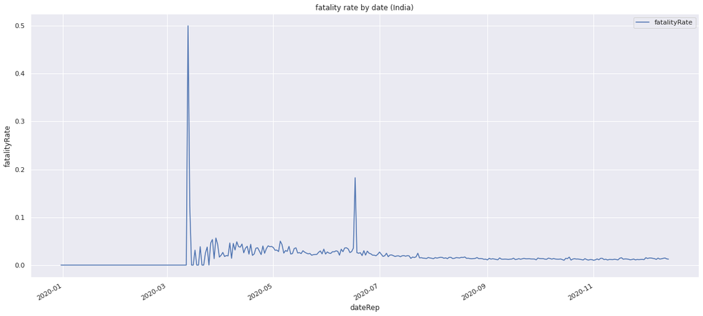

```python
#taking a look of the fatality rate by date
ax = dfindia.plot(x = 'dateRep', y ='fatalityRate', figsize=(20,9), title='fatality rate by date (India)')
ax.set_xlabel("dateRep")
ax.set_ylabel("fatalityRate")
```

```python
#Breaking down record numbers by country
bycoun = covid19_df.groupby(['countriesAndTerritories']).count().reset_index()
bycoun.head(10)
```

|  | countriesAndTerritories | dateRep | day | month | year | cases | deaths | geoId | countryterritoryCode | popData2019 | continentExp | Cumulative_number_for_14_days_of_COVID-19_cases_per_100000 |
| --- | --- | --- | --- | --- | --- | --- | --- | --- | --- | --- | --- | --- |
| 0 | Afghanistan | 340 | 340 | 340 | 340 | 340 | 340 | 340 | 340 | 340 | 340 | 327 |
| 1 | Albania | 281 | 281 | 281 | 281 | 281 | 281 | 281 | 281 | 281 | 281 | 268 |
| 2 | Algeria | 345 | 345 | 345 | 345 | 345 | 345 | 345 | 345 | 345 | 345 | 332 |
| 3 | Andorra | 276 | 276 | 276 | 276 | 276 | 276 | 276 | 276 | 276 | 276 | 263 |
| 4 | Angola | 268 | 268 | 268 | 268 | 268 | 268 | 268 | 268 | 268 | 268 | 255 |
| 5 | Anguilla | 263 | 263 | 263 | 263 | 263 | 263 | 263 | 263 | 263 | 263 | 250 |
| 6 | Antigua_and_Barbuda | 270 | 270 | 270 | 270 | 270 | 270 | 270 | 270 | 270 | 270 | 257 |
| 7 | Argentina | 283 | 283 | 283 | 283 | 283 | 283 | 283 | 283 | 283 | 283 | 270 |
| 8 | Armenia | 341 | 341 | 341 | 341 | 341 | 341 | 341 | 341 | 341 | 341 | 328 |
| 9 | Aruba | 267 | 267 | 267 | 267 | 267 | 267 | 267 | 267 | 267 | 267 | 254 |

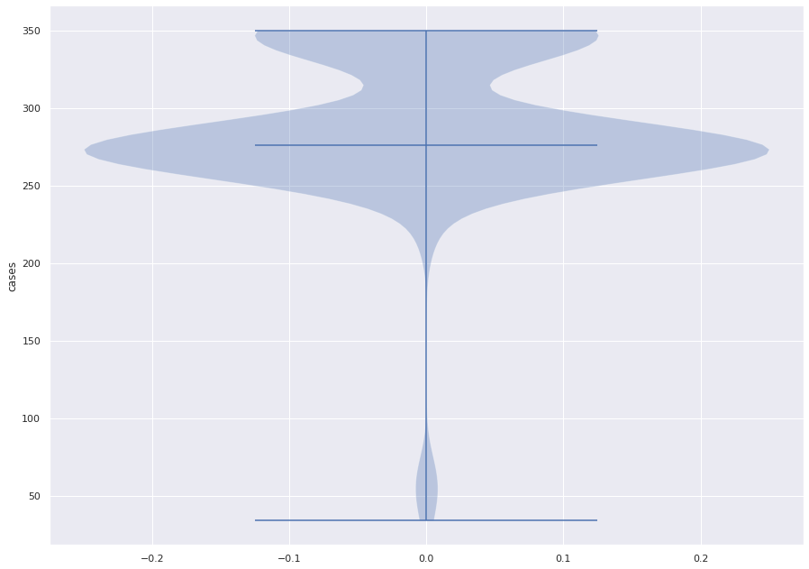

```python
# Voilin Plot of the cases by country
plt.violinplot(bycoun['cases'], [0],
               points=100,
               bw_method='scott',
               showmeans=False,
               showextrema=True,
               showmedians=True)

plt.ylabel('cases')
plt.show()
```

```python
#first lets compare some countries without scaling, let's find countries with the same records as the US
bycoun.loc[bycoun['countriesAndTerritories'] == 'United_States_of_America']
```

|  | countriesAndTerritories | dateRep | day | month | year | cases | deaths | geoId | countryterritoryCode | popData2019 | continentExp | Cumulative_number_for_14_days_of_COVID-19_cases_per_100000 |
| --- | --- | --- | --- | --- | --- | --- | --- | --- | --- | --- | --- | --- |
| 203 | United_States_of_America | 350 | 350 | 350 | 350 | 350 | 350 | 350 | 350 | 350 | 350 | 337 |

```python
# let's pick Belgium to compare with the US
dfbe=covid19_df[covid19_df["countriesAndTerritories"] == "Belgium"].copy().sort_values(by='dateRep').reset_index().drop(columns=['index'])
#creating new features cumCases
dfbe['belgiumCumulativeCases'] = dfbe['cases'].cumsum(axis = 0)
dfbe[60:65]
```

|  | dateRep | day | month | year | cases | deaths | countriesAndTerritories | geoId | countryterritoryCode | popData2019 | continentExp | Cumulative_number_for_14_days_of_COVID-19_cases_per_100000 | belgiumCumulativeCases |
| --- | --- | --- | --- | --- | --- | --- | --- | --- | --- | --- | --- | --- | --- |
| 60 | 2020-02-29 | 29 | 2 | 2020 | 0 | 0 | Belgium | BE | BEL | 11455519.0 | Europe | 0.000000 | 1 |
| 61 | 2020-03-01 | 1 | 3 | 2020 | 18 | 0 | Belgium | BE | BEL | 11455519.0 | Europe | 0.000000 | 19 |
| 62 | 2020-03-02 | 2 | 3 | 2020 | 0 | 0 | Belgium | BE | BEL | 11455519.0 | Europe | 0.157130 | 19 |
| 63 | 2020-03-03 | 3 | 3 | 2020 | 19 | 0 | Belgium | BE | BEL | 11455519.0 | Europe | 0.157130 | 38 |
| 64 | 2020-03-04 | 4 | 3 | 2020 | 34 | 0 | Belgium | BE | BEL | 11455519.0 | Europe | 0.322988 | 72 |

```python
# Also compare it with india
dfindia=covid19_df[covid19_df["countriesAndTerritories"] == "India"].copy().sort_values(by='dateRep').reset_index().drop(columns=['index'])
#creating new features cumCases
dfindia['indiaCumulativeCases'] = dfindia['cases'].cumsum(axis = 0)
dfindia[60:65]
```

|  | dateRep | day | month | year | cases | deaths | countriesAndTerritories | geoId | countryterritoryCode | popData2019 | continentExp | Cumulative_number_for_14_days_of_COVID-19_cases_per_100000 | indiaCumulativeCases |
| --- | --- | --- | --- | --- | --- | --- | --- | --- | --- | --- | --- | --- | --- |
| 60 | 2020-02-29 | 29 | 2 | 2020 | 0 | 0 | India | IN | IND | 1.366418e+09 | Asia | 0.000000 | 3 |
| 61 | 2020-03-01 | 1 | 3 | 2020 | 0 | 0 | India | IN | IND | 1.366418e+09 | Asia | 0.000000 | 3 |
| 62 | 2020-03-02 | 2 | 3 | 2020 | 0 | 0 | India | IN | IND | 1.366418e+09 | Asia | 0.000000 | 3 |
| 63 | 2020-03-03 | 3 | 3 | 2020 | 2 | 0 | India | IN | IND | 1.366418e+09 | Asia | 0.000146 | 5 |
| 64 | 2020-03-04 | 4 | 3 | 2020 | 1 | 0 | India | IN | IND | 1.366418e+09 | Asia | 0.000220 | 6 |

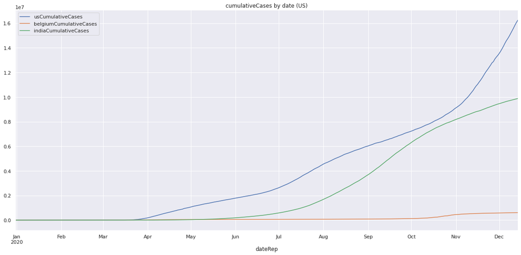

```python
# Plotting them together to compare
ax2 = dfus.plot(x = 'dateRep', y ='usCumulativeCases', figsize=(20,9), title='cumulativeCases by date (US)')
dfbe.plot(x = 'dateRep', y ='belgiumCumulativeCases', figsize=(20,9), ax=ax2)
dfindia.plot(x = 'dateRep', y ='indiaCumulativeCases', figsize=(20,9), ax=ax2)
```

```python
# We cannot compare these two in the same graph because the population difference is huge
# Choosing cumulative cases as the variable to scale
X = dfus['usCumulativeCases'].values.reshape(-1, 1)
Y = dfbe['belgiumCumulativeCases'].values.reshape(-1, 1)
Z = dfindia['indiaCumulativeCases'].values.reshape(-1, 1)
```

```python
#adding to addition columns Stan and Minm, they are the cumulative cases after standard scaling and min max scaling, respectively
dfus['usStandard'] = StandardScaler().fit_transform(X)
dfus['usMinmax'] = MinMaxScaler().fit_transform(X)
dfbe['belgiumStandard'] = StandardScaler().fit_transform(Y)
dfbe['belgiumMinmax'] = MinMaxScaler().fit_transform(Y)
dfindia['indiaStandard'] = StandardScaler().fit_transform(Z)
dfindia['indiaMinmax'] = MinMaxScaler().fit_transform(Z)
# Thoughts on adding other countries to this analysis ?


# OTHER SCALING METHODS
#dfus['Maxa'] = MaxAbsScaler().fit_transform(X)
#dfus['Robu'] = RobustScaler(quantile_range=(25, 75)).fit_transform(X)
#dfus['Yeoj'] = PowerTransformer(method='yeo-johnson').fit_transform(X)
#dfus['QUnif'] = QuantileTransformer(output_distribution='uniform').fit_transform(X)
#dfus['QNorm'] = QuantileTransformer(output_distribution='normal').fit_transform(X)
#dfus['Norm'] = Normalizer().fit_transform(X)
```

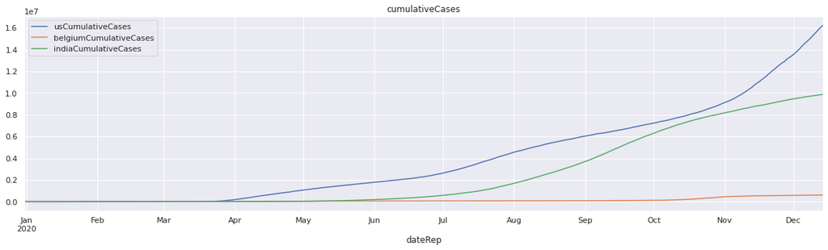

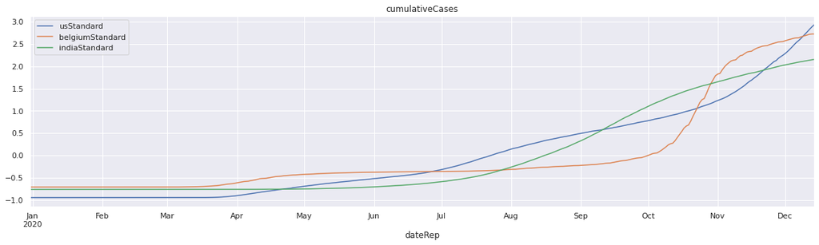

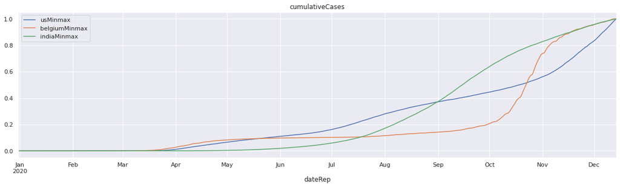

```python
#Plotting the 3 scales against each other
sns.set(rc={'figure.figsize':(20, 5)})
ax5 = dfus.plot(x='dateRep', y='usCumulativeCases', title='cumulativeCases');
dfbe.plot(x='dateRep', y='belgiumCumulativeCases', title='cumulativeCases', ax=ax5);
dfindia.plot(x='dateRep', y='indiaCumulativeCases', title='cumulativeCases', ax=ax5);

ax6 = dfus.plot(x='dateRep', y='usStandard', title='cumulativeCases Standard Scale');
dfbe.plot(x='dateRep', y='belgiumStandard', title='cumulativeCases', ax=ax6);
dfindia.plot(x='dateRep', y='indiaStandard', title='cumulativeCases', ax=ax6);

ax7 = dfus.plot(x='dateRep', y='usMinmax', title='cumulativeCases Min-Max Scale');
dfbe.plot(x='dateRep', y='belgiumMinmax', title='cumulativeCases', ax=ax7);
dfindia.plot(x='dateRep', y='indiaMinmax', title='cumulativeCases', ax=ax7);
```

```python
#
# Can I try something else here maybe using a forecasting libary
# setting up df for fb prophet
# fbdf = pd.DataFrame(dfus.sort_values(by='dateRep').reset_index(), columns = ['dateRep', 'cumulativeCases'])
# fbdf = fbdf.rename(columns={"dateRep": "ds", "cumulativeCases": "y"})
# fbdf.head()

# ADDITIONAL POINTS : Why is it all NaN ? What would be an alternate solution/finding/recommendation ?
# It is all NaN because we the dataframe does not have the cases column, need to added the cases column and recalculate the cumulativecases column
```

```python
# Can I try something else here maybe using a forecasting libary
# setting up df for fb prophet
fbdf = pd.DataFrame(dfus.sort_values(by='dateRep').reset_index(), columns = ['dateRep', 'cases'])
fbdf['cumulativeCases'] = fbdf['cases'].cumsum(axis = 0)

fbdf = fbdf.rename(columns={"dateRep": "ds", "cumulativeCases": "y"})
fbdf.head()
```

|  | ds | cases | y |
| --- | --- | --- | --- |
| 0 | 2019-12-31 | 0 | 0 |
| 1 | 2020-01-01 | 0 | 0 |
| 2 | 2020-01-02 | 0 | 0 |
| 3 | 2020-01-03 | 0 | 0 |
| 4 | 2020-01-04 | 0 | 0 |

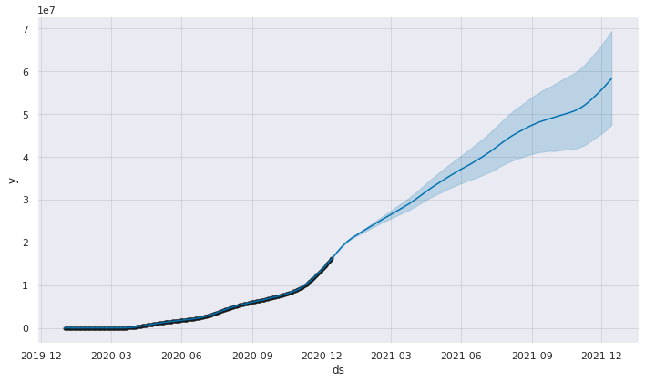

```python
# Will need some tweaking here
ml = Prophet(daily_seasonality=True,yearly_seasonality=True)
ml.fit(fbdf)
future = ml.make_future_dataframe(periods=365)
forecast = ml.predict(future)
plot1 = ml.plot(forecast)
```

FINDINGS/ANALYSIS:

Questions

- What are the management and analytical questions associated with this problem?

The management and analytical questions associated with this problem are the the covid cases for different countries. Which country's pandemic is more serious than others. What are the deaths over time for a country. The cumulative cases for a countries. The correlation between different variables in the dataset. The cases in the future.

- What are some of the assumptions if any ?

One assumption is data set is accurate. If the dataset is not acuurate then it does not make sense to make any comparsion and analysis through dataset.